# House Price

```r
library(knitr)
library(ggplot2)
library(plyr)
library(dplyr)
library(corrplot)
library(gridExtra)
library(scales)
library(Rmisc)
library(ggrepel)
library(randomForest)
library(psych)
library(sqldf)
```

```r
getwd()
```

```
[1] "C:/Users/11367/Desktop/House Price"
```

```r
#读取全部数据集
train = read.csv("train.csv", stringsAsFactors = F)
test = read.csv("test.csv", stringsAsFactors = F)
```

```r
#train数据集查看
dim(train)
dim(test)
str(train[,c(1:10, 81)])
```

```
[1] 1460   81
[1] 1459   80
'data.frame':   1460 obs. of  11 variables:
 $ Id         : int  1 2 3 4 5 6 7 8 9 10 ...
 $ MSSubClass : int  60 20 60 70 60 50 20 60 50 190 ...
 $ MSZoning   : chr  "RL" "RL" "RL" "RL" ...
 $ LotFrontage: int  65 80 68 60 84 85 75 NA 51 50 ...
 $ LotArea    : int  8450 9600 11250 9550 14260 14115 10084 10382 6120 7420 ...
 $ Street     : chr  "Pave" "Pave" "Pave" "Pave" ...
 $ Alley      : chr  NA NA NA NA ...
 $ LotShape   : chr  "Reg" "Reg" "IR1" "IR1" ...
 $ LandContour: chr  "Lvl" "Lvl" "Lvl" "Lvl" ...
 $ Utilities  : chr  "AllPub" "AllPub" "AllPub" "AllPub" ...
 $ SalePrice  : int  208500 181500 223500 140000 250000 143000 307000 200000 129900 118000 ...
```

```r
#删除train$Id、test$Id (不是影响因子)
test_labels = test$Id
test$Id = NULL
train$Id = NULL
```

```r
#test中没有目标变量，因此要增加SalePrice
test$SalePrice = NA

#合并train、test
all = rbind(train, test)
dim(all)
```

```
[1] 2919   80
```

# 1 探索变量(EDA)

## 1.1 探索目标变量

```
[1] 34900
[1] 755000
   Min. 1st Qu.  Median    Mean 3rd Qu.    Max.    NA's
  34900  129975  163000  180921  214000  755000    1459
```

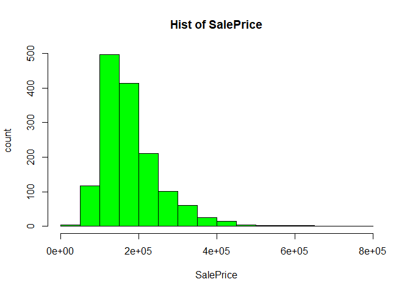

```r
#all的目标变量SalePrice => 连续型变量

#1、画直方图
min(all$SalePrice,na.rm = T)
max(all$SalePrice,na.rm = T)
hist(all$SalePrice,col = 'green', xlab='SalePrice', ylab = 'count', main='Hist of SalePrice')

#2、summary(连续型变量) => 最大值、最小值、均值、中位数、分位点、缺失值个数
summary(all$SalePrice)
```

## 1.2 探索(数值)特征

### 1.2.1 可视化协方差矩阵

```
有 37 个数值型变量

|与SalePrice相关性|>0.5的数值型变量：
                  [,1]
SalePrice    1.0000000
OverallQual  0.7909816
GrLivArea    0.7086245
GarageCars   0.6404092
GarageArea   0.6234314
TotalBsmtSF  0.6135806
X1stFlrSF    0.6058522
FullBath     0.5606638
TotRmsAbvGrd 0.5337232
YearBuilt    0.5228973
YearRemodAdd 0.5071010
```

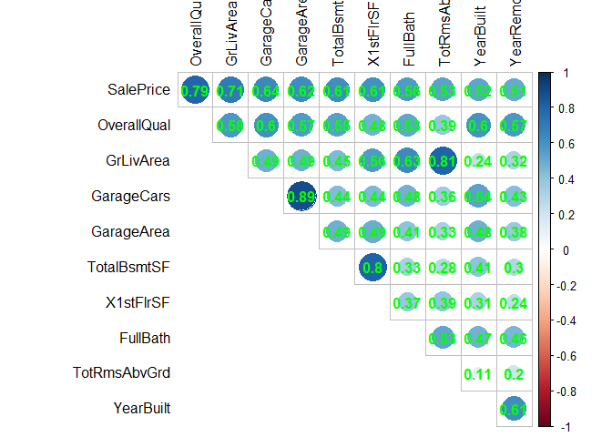

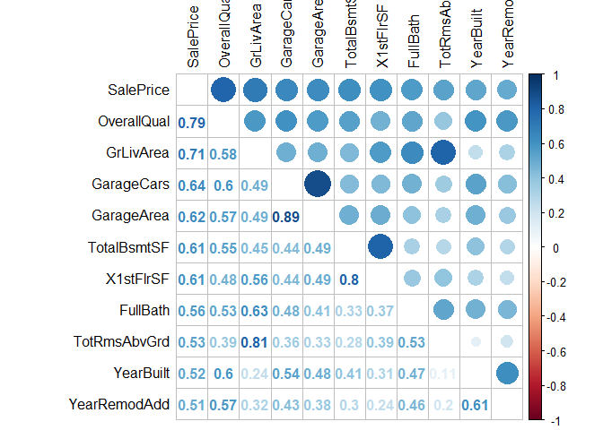

```r
#1、获得最初所有数值特征
numVar_index = which(sapply(all, is.numeric))                #最初的数值特征的index向量(带有name)
numVar_name_initial = names(numVar_index)                            #最初的数值特征的name
cat('有', length(numVar_index), '个数值型变量','\n')
cat('\n')



#2、所有数值特征的协方差矩阵
all_numVar = all[, numVar_index]                             #所有数值特征组成新数据框all_numVar
cor = cor(all_numVar, use="pairwise.complete.obs")           #all_numVar的协方差矩阵(计算时省去缺失值)



#3、从大到小排列：SalePrice与数值特征的相关性
cor_sorted = as.matrix(sort(cor[,'SalePrice'], decreasing = TRUE))


corHigh_matrix=as.matrix(cor_sorted[abs(cor_sorted)>0.5,])
corHigh_name=row.names(corHigh_matrix)

cat('|与SalePrice相关性|>0.5的数值型变量：','\n')
corHigh_matrix



#4、可视化(与SalePrice相关性强的)数值特征的相关性矩阵
cor_high = cor[corHigh_name,corHigh_name]


corrplot(cor_high, addCoef.col = 'green', type = 'upper', diag = F, tl.pos = 'lt', tl.col = "black")
corrplot.mixed(cor_high, tl.col="black", tl.pos = "lt")
```

### 1.2.2 与SalePrice相关性最强的数值特征：OverallQual(整体质量)

```
[1] 10

  1   2   3   4   5   6   7   8   9  10
  4  13  40 226 825 731 600 342 107  31
```

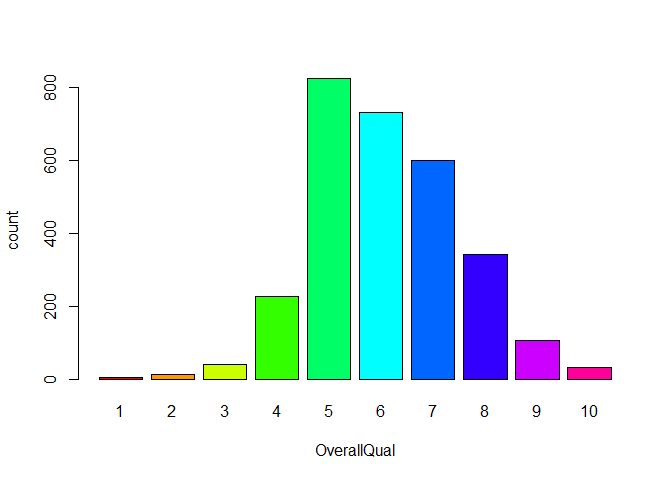

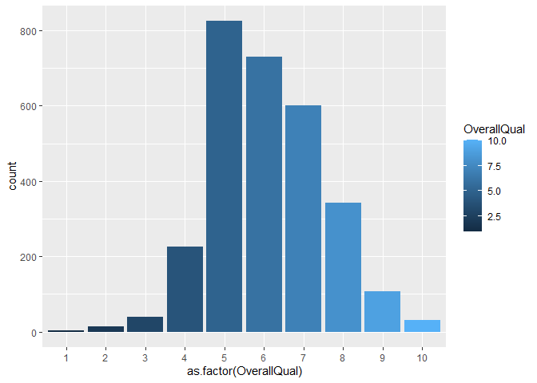

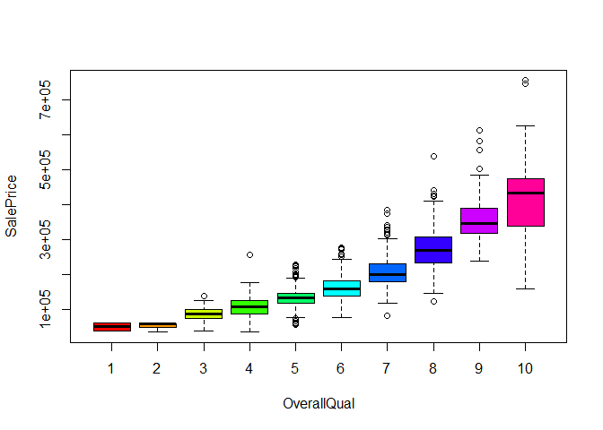

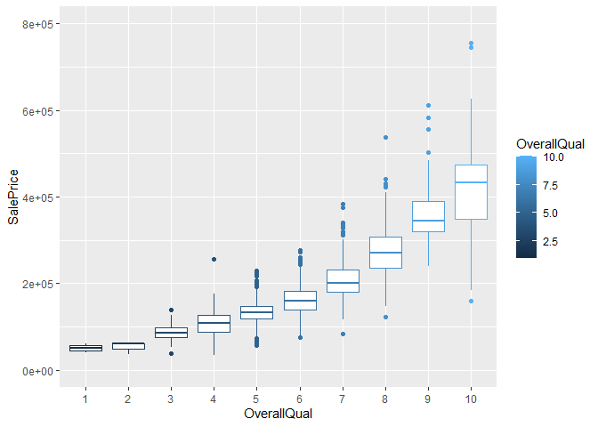

```r
length(table(all$OverallQual))         #分类变量
table(all$OverallQual)                 #(数值型)有序分类变量

#可视化
count=table(all$OverallQual)
barplot(count, col=rainbow(10), ylab = 'count', xlab = 'OverallQual')
qplot(as.factor(OverallQual), data=all, geom='bar', fill=OverallQual, ylab='count')

boxplot(all$SalePrice~all$OverallQual , col=rainbow(10) , xlab = 'OverallQual' , ylab = 'SalePrice')
qplot(interaction(OverallQual),SalePrice,data=all,geom='boxplot',col=OverallQual , xlab='OverallQual',  ylim = c(0,800000))
```

可视化OverallQual与SalePrice的关系后：没有发现异常值(除了OverallQual为4时有一个值有点异常)

### 1.2.3 与SalePrice相关性第二强的数值特征：GrLivArea（生活区面积）

```
[1] 1292
   Min. 1st Qu.  Median    Mean 3rd Qu.    Max.
    334    1126    1444    1501    1744    5642
[1]  524 1299
     SalePrice GrLivArea OverallQual
524     184750      4676          10
1299    160000      5642          10
```

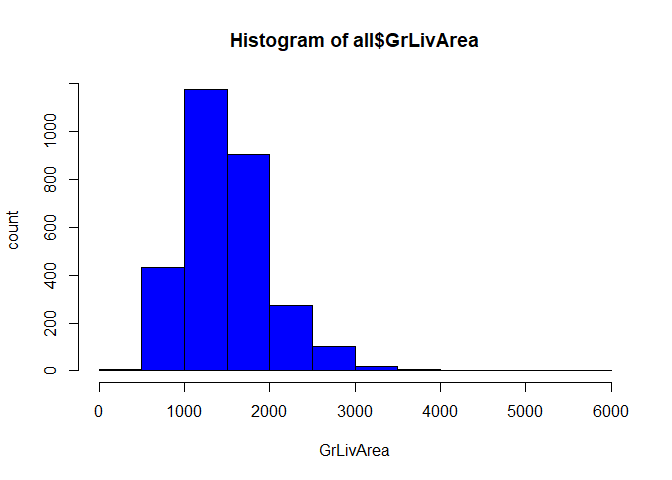

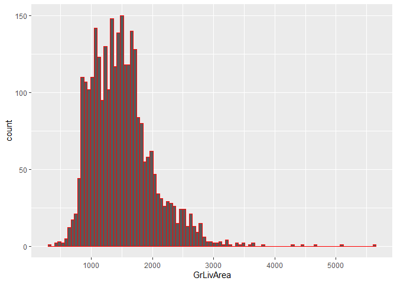

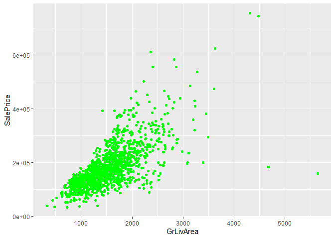

```r
length(table(all$GrLivArea))            #连续型变量
summary(all$GrLivArea)

#可视化
hist(all$GrLivArea,col='blue', xlab='GrLivArea', ylab='count')
qplot(GrLivArea,data = all, geom = 'histogram',col=I('red'),bins='100' , ylab = 'count')

qplot(GrLivArea,SalePrice,data=all,col=I('green'))



#找到2个异常值点
which(all$GrLivArea>4500 & all$SalePrice<200000)

all[c(524, 1299), c('SalePrice', 'GrLivArea', 'OverallQual')]          #这两个异常值点的 售价、GrLivArea, OverallQual
```

可视化GrLivArea与SalePrice的关系后：找到2个异常值点（房屋524、1299） 现在还不能把它们剔除，因为剔除异常值可能会很危险

# 2 预处理数据

**本节中将所有特征都转换为两类：数值特征、factor型特征**

## 2.1 处理(日期)数值特征

将部分数值特征转化为factor 因为它们是：(数值型)无序分类变量 => 需要one-hot encoding

```
 [1] "MSSubClass"    "LotFrontage"   "LotArea"       "OverallQual"
 [5] "OverallCond"   "YearBuilt"     "YearRemodAdd"  "MasVnrArea"
 [9] "BsmtFinSF1"    "BsmtFinSF2"    "BsmtUnfSF"     "TotalBsmtSF"
[13] "X1stFlrSF"     "X2ndFlrSF"     "LowQualFinSF"  "GrLivArea"
[17] "BsmtFullBath"  "BsmtHalfBath"  "FullBath"      "HalfBath"
[21] "BedroomAbvGr"  "KitchenAbvGr"  "TotRmsAbvGrd"  "Fireplaces"
[25] "GarageYrBlt"   "GarageCars"    "GarageArea"    "WoodDeckSF"
[29] "OpenPorchSF"   "EnclosedPorch" "X3SsnPorch"    "ScreenPorch"
[33] "PoolArea"      "MiscVal"       "MoSold"        "YrSold"
[37] "SalePrice"

[1] 5
[1] 12

2006 2007 2008 2009 2010
 619  692  622  647  339

  1   2   3   4   5   6   7   8   9  10  11  12
122 133 232 279 394 503 446 233 158 173 142 104
```

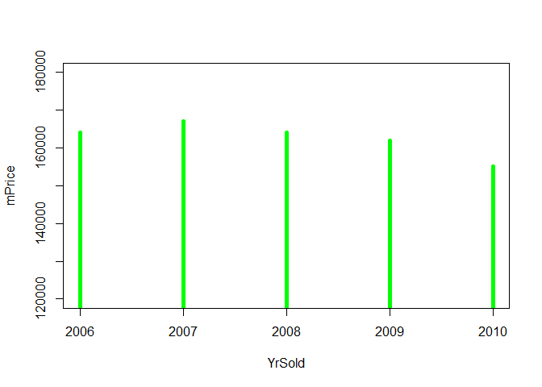

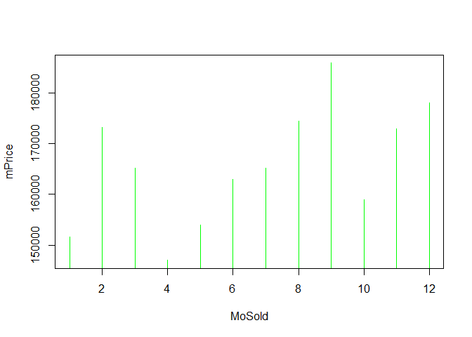

```r
names(all[,sapply(all, is.numeric)])
cat('\n')

#1、YrSold、MoSold
length(table(all$YrSold))        #分类变量
length(table(all$MoSold))        #分类变量
table(all$YrSold)
table(all$MoSold)

#  分组求得每组SalePrice的中位数mPrice => 可视化mPrice的趋势
SalePrice_complete=all[!is.na(all$SalePrice),]
mPrice_YrSold=data.frame(sqldf('select YrSold,median(SalePrice)as mPrice from SalePrice_complete group by YrSold'))
mPrice_MoSold=data.frame(sqldf('select MoSold,median(SalePrice)as mPrice from SalePrice_complete group by MoSold'))

plot(mPrice_YrSold$YrSold,mPrice_YrSold$mPrice,type ='h',col='green',lwd=5,ylim = c(120000,180000), xlab='YrSold', ylab='mPrice')
plot(mPrice_MoSold$MoSold,mPrice_MoSold$mPrice,col='green', type ='h', xlab='MoSold', ylab='mPrice')


#  由图可知，YrSold、MoSold是(数值型)无序分类变量，应该转化为factor
all$MoSold = as.factor(all$MoSold)
all$YrSold = as.factor(all$YrSold)
```

每月的房价是周期性变化 =>所以月份应该是：无序分类变量 2006年-2007年，年份也应该是：无序分类变量

```r
#2、MSSubClass
length(table(all$MSSubClass))     #分类变量
table(all$MSSubClass)             #(数值型)无序分类变量

#  转化为factor
all$MSSubClass = as.factor(all$MSSubClass)

#  level重塑
all$MSSubClass = revalue(all$MSSubClass, c('20'='1 story 1946+', '30'='1 story 1945-', '40'='1 story unf attic', '45'='1,5 story unf', '50'='1,5 story fin', '60'='2 story 1946+', '70'='2 story 1945-', '75'='2,5 story all ages', '80'='split/multi level', '85'='split foyer', '90'='duplex all style/age', '120'='1 story PUD 1946+', '150'='1,5 story PUD all', '160'='2 story PUD 1946+', '180'='PUD multilevel', '190'='2 family conversion'))
```

```
[1] 16

  20   30   40   45   50   60   70   75   80   85   90  120  150  160  180  190
1079  139    6   18  287  575  128   23  118   48  109  182    1  128   17   61
```

## 2.2 处理缺失值 + 分组处理字符特征

处理字符特征：标签编码+as.factor转换

### 2.2.1 寻找有缺失值的特征

```r
#判断哪些变量有缺失值
NACol_index = which(colSums(is.na(all)) > 0)

#对有缺失值的变量，按缺失值由多到少输出
sort(colSums(is.na(all[,NACol_index])), decreasing = T)
```

```
      PoolQC  MiscFeature        Alley        Fence    SalePrice  FireplaceQu
        2909         2814         2721         2348         1459         1420
 LotFrontage  GarageYrBlt GarageFinish   GarageQual   GarageCond   GarageType
         486          159          159          159          159          157
    BsmtCond BsmtExposure     BsmtQual BsmtFinType2 BsmtFinType1   MasVnrType
          82           82           81           80           79           24
  MasVnrArea     MSZoning    Utilities BsmtFullBath BsmtHalfBath   Functional
          23            4            2            2            2            2
 Exterior1st  Exterior2nd   BsmtFinSF1   BsmtFinSF2    BsmtUnfSF  TotalBsmtSF
           1            1            1            1            1            1
  Electrical  KitchenQual   GarageCars   GarageArea     SaleType
           1            1            1            1            1
```

SalePrice有1459个缺失值，与test的行数相等 => all中SalePrice的缺失值都为test中SalePrice的缺失值

### 2.2.2 填充缺失值 + (按缺失值)分组处理字符特征

以下用’None’填充的都是因为官方规定此特征的NA=‘None’，其他的用众数、或中位数填充 1、有序=>标签编码 ； 2、无序=>(one-hot encoding前)转化为factor

```r
#一、Pool(泳池)：与泳池有关的变量(有2个)  => PoolArea(泳池大小)、PoolQC(泳池质量)

#只有PoolQC有缺失值(2909个)

#1、填充PoolQC
length(table(all$PoolQC))                       #分类变量
table(all$PoolQC)                               #(字符型)有序分类变量：标签编码

all$PoolQC[is.na(all$PoolQC)] = 'None'
table(all$PoolQC)



#2、标签编码PoolQC
Qualities = c('None' = 0, 'Po' = 1, 'Fa' = 2, 'TA' = 3, 'Gd' = 4, 'Ex' = 5)
all$PoolQC=as.numeric(revalue(all$PoolQC, Qualities))
table(all$PoolQC)



#3、检查Pool变量之间的异常值：all$PoolArea>0的，all$PoolQC一定不为0
all[all$PoolArea>0 & all$PoolQC==0 , c('PoolArea', 'PoolQC', 'OverallQual')]      #具有异常值

#根据OverallQual(房屋的总体质量)来估算这3个异常的PoolQC:
all$PoolQC[2421] = 2
all$PoolQC[2504] = 3
all$PoolQC[2600] = 2
```

```
[1] 3

Ex Fa Gd
 4  2  4

  Ex   Fa   Gd None
   4    2    4 2909

   0    2    4    5
2909    2    4    4
     PoolArea PoolQC OverallQual
2421      368      0           4
2504      444      0           6
2600      561      0           3
```

```
[1] 4

Gar2 Othr Shed TenC
   5    4   95    1

Gar2 None Othr Shed TenC
   5 2814    4   95    1
```

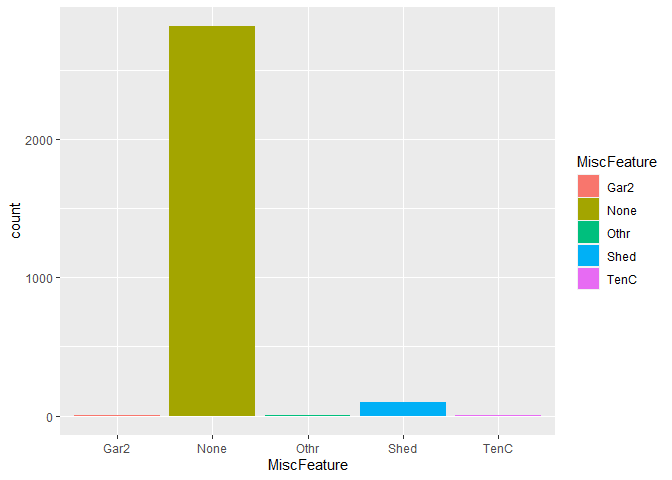

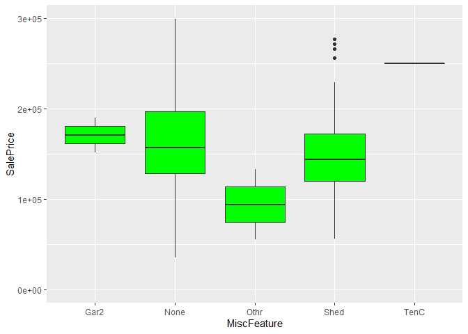

```r
#二、MiscFeature(其他功能)

#填充MiscFeature
length(table(all$MiscFeature))                       #分类变量
table(all$MiscFeature)

all$MiscFeature[is.na(all$MiscFeature)]='None'
table(all$MiscFeature)


qplot(MiscFeature, data=all, geom = 'bar', fill=MiscFeature, ylab='count')
qplot(MiscFeature,SalePrice, data=all, geom = 'boxplot',fill=I('green'), ylim=c(0,300000))


#(字符型)无序分类变量：转化为factor
all$MiscFeature = as.factor(all$MiscFeature)
```

```r
#三、Alley(小径)

#填充Alley
length(table(all$Alley))                #分类变量
table(all$Alley)                        #(字符型)无序分类变量：转化为factor

all$Alley[is.na(all$Alley)]='None'
table(all$Alley)


all$Alley = as.factor(all$Alley)
```

```
[1] 2

Grvl Pave
 120   78

Grvl None Pave
 120 2721   78
```

```
[1] 4

GdPrv  GdWo MnPrv  MnWw
  118   112   329    12

GdPrv  GdWo MnPrv  MnWw  None
  118   112   329    12  2348
     Fence   median(SalePrice)
[1,] "GdPrv" "167500"
[2,] "GdWo"  "138750"
[3,] "MnPrv" "137450"
[4,] "MnWw"  "130000"
[5,] "None"  "173000"
```

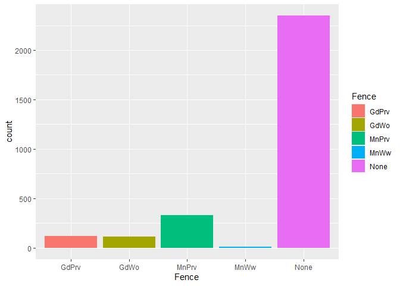

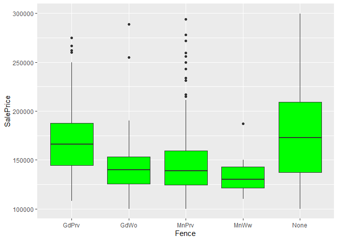

```r
#四、Fence(栅栏)


#填充Fence
length(table(all$Fence))                  #分类变量
table(all$Fence)

all$Fence[is.na(all$Fence)]='None'
table(all$Fence)


SalePrice_complete=all[!is.na(all$SalePrice),]
as.matrix(sqldf('select Fence,median(SalePrice) from SalePrice_complete group by Fence'))
qplot(Fence, data=all, geom = 'bar', fill=Fence, ylab='count')
qplot(Fence, SalePrice, data=all, geom = 'boxplot',fill=I('green'), ylim=c(100000,300000))


#(字符型)无序分类变量：转化为factor
all$Fence = as.factor(all$Fence)
```

```
[1] 5

 Ex  Fa  Gd  Po  TA
 43  74 744  46 592

  Ex   Fa   Gd None   Po   TA
  43   74  744 1420   46  592
[1] 5

   0    1    2    3    4
1420 1268  219   11    1
[1] Fireplaces  FireplaceQu OverallQual
<0 rows> (or 0-length row.names)
```

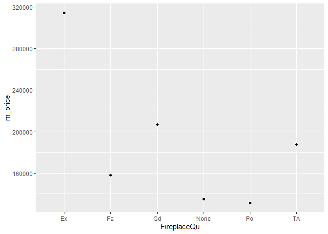

```r
#五、Fireplac(壁炉)：与壁炉有关的变量(有两个)  => FireplaceQu(壁炉质量)、Fireplaces(壁炉个数)

#只有FireplaceQu有缺失值

#1、填充FireplaceQu
length(table(all$FireplaceQu))                      #分类变量
table(all$FireplaceQu)

all$FireplaceQu[is.na(all$FireplaceQu)] ='None'
table(all$FireplaceQu)


SalePrice_complete=all[!is.na(all$SalePrice),]
FireplaceQu_SalePrice=sqldf('select FireplaceQu,median(SalePrice)as m_price from SalePrice_complete group by FireplaceQu')
qplot(FireplaceQu,m_price,data=FireplaceQu_SalePrice)


#   (字符型)有序分类变量：标签编码
all$FireplaceQu = as.numeric(revalue(all$FireplaceQu, Qualities))




#2、Fireplaces
length(table(all$Fireplaces))                     #分类变量
table(all$Fireplaces)                             #(数值型)有序分类变量




#3、这两个变量之间没有异常值
all[all$Fireplaces>0 & all$FireplaceQu==0 , c('Fireplaces', 'FireplaceQu', 'OverallQual')]
```

```
[1] 128

[1] 4

 IR1  IR2  IR3  Reg
 968   76   16 1859

   0    1    2    3
  16   76  968 1859

[1] 5

 Corner CulDSac     FR2     FR3  Inside
    511     176      85      14    2133

 Corner CulDSac     FR2     FR3  Inside
    511     176      85      14    2133

[1] 1951
```

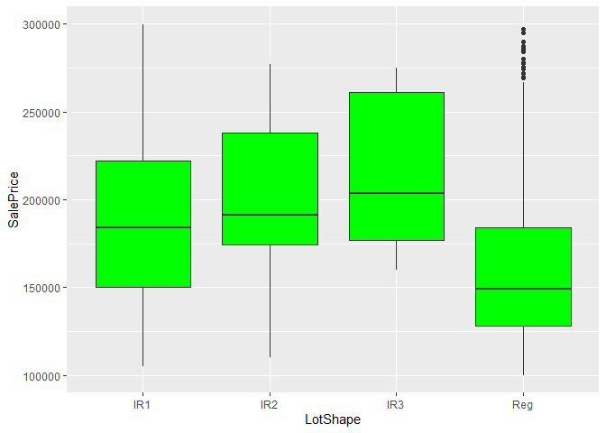

```r
#六、Lot(地皮)：与地段有关的变量(有4个) =>LotArea(地段面积)、LotConfig(地段配置)、LotFrontage(地段临街长度)、LotShape(地段形状)

#只有LotFrontage有缺失值

#1、填充LotFrontage
length(table(all$LotFrontage))                     #连续型变量 => 分组，用每组中位数填充

#   按Neighborhood分组，用每组中位数填充
for (i in 1:nrow(all)){
        if(is.na(all$LotFrontage[i])){
               all$LotFrontage[i] = as.numeric(median(all$LotFrontage[all$Neighborhood==all$Neighborhood[i]], na.rm=TRUE))
        }
}
cat('\n')




#2、LotShape
length(table(all$LotShape))                        #分类变量
table(all$LotShape)                                #字符型分类变量

qplot(LotShape, SalePrice, data=all, geom = 'boxplot',fill=I('green'), ylim=c(100000,300000))

#   (字符型)有序分类变量：标签编码
all$LotShape = as.numeric(revalue(all$LotShape, c('IR3'=0, 'IR2'=1, 'IR1'=2, 'Reg'=3)))
table(all$LotShape)
cat('\n')




#3、LotConfig
length(table(all$LotConfig))                       #分类变量
table(all$LotConfig)                               #(字符型)无序分类变量：转换为factor


all$LotConfig = as.factor(all$LotConfig)
table(all$LotConfig)
cat('\n')




#4、LotArea
length(table(all$LotArea))                         #连续型变量
```

```
[1] 157
```

|  | GarageCars | GarageArea | GarageType | GarageCond | GarageQual | GarageFinish |
| --- | --- | --- | --- | --- | --- | --- |
| 2127 | 1 | 360 | Detchd | NA | NA | NA |
| 2577 | NA | NA | Detchd | NA | NA | NA |

```
[1] 158

[1] 103


  TA   Fa   Gd   Po   Ex
2654   74   15   14    3

  TA   Fa   Gd   Po   Ex
2604  124   24    5    3

 Unf  RFn  Fin
1230  811  719

   0    1    2    3    4    5
 158   14   74 2655   15    3

   0    1    2    3    4    5
 158    5  124 2605   24    3

   0    1    2    3
 158 1231  811  719

[1] 6

 2Types  Attchd Basment BuiltIn CarPort  Detchd
     23    1723      36     186      15     778

[1] 6

   0    1    2    3    4    5
 157  776 1594  374   16    1
[1] 603
```

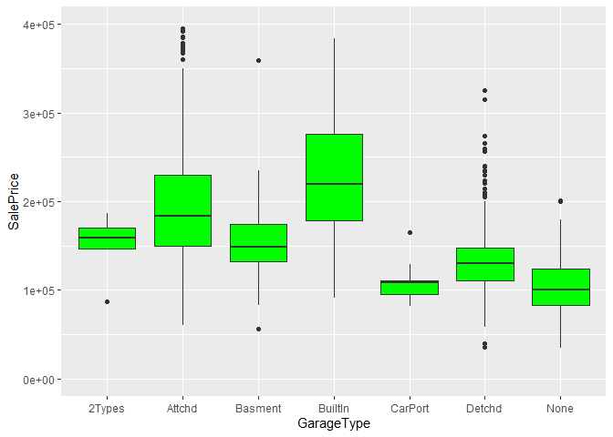

```r
#七、Garage(车库)：与车库有关的变量(有7个)  =>  GarageArea(车库大小)、GarageCars(车库车位)、GarageCond(车库环境)、GarageFinish(车库内部完成度)、GarageQual(车库质量)、GarageType(车库类型)、GarageYrBlt(车库建立年份)

#这7个变量都有缺失值
#其中4个变量(GarageYrBlt、GarageFinish、GarageQual、GarageCond)缺失值个数相同(原因也相同：都因为没有车库)：159个缺失值
#有1个变量(GarageType)缺失值比那4个少俩：157个缺失值
#另2个变量(GarageCars、GarageArea)：只有1个缺失值




#1、检查Garage变量缺失值之间的情况
#GarageFinish、GarageQual、GarageCond(缺失值个数相同，且NA='None'), 但是都比GarageType多2个缺失值


#   判断GarageFinish、GarageQual、GarageCond、GarageType有缺失值的房屋是否都相同   => 是
length(which(is.na(all$GarageType) & is.na(all$GarageFinish) & is.na(all$GarageCond) & is.na(all$GarageQual)))

kable(all[!is.na(all$GarageType) & is.na(all$GarageFinish) , c('GarageCars', 'GarageArea', 'GarageType', 'GarageCond', 'GarageQual', 'GarageFinish')])

#    区别在于房屋2127和2577：房屋2577没有车库，但房屋2127实际上有车库  => 将GarageType[2577]修改为NA
all$GarageType[2577] = NA

length(which(is.na(all$GarageType) & is.na(all$GarageFinish) & is.na(all$GarageCond) & is.na(all$GarageQual)))
cat('\n')




#2、填充GarageYrBlt(车库建立年份)
length(table(all$GarageYrBlt))                                                     #连续型变量

all$GarageYrBlt[is.na(all$GarageYrBlt)]=all$YearBuilt[is.na(all$GarageYrBlt)]      #用房屋建立年份填充
cat('\n')




#3、填充GarageFinish、GarageQual、GarageCond       (都为(字符型)有序分类变量)

#1)为房屋2127的这三个特征各自填补缺失值 (用众数)   (房屋2127有Garage，所以不能填'None')
sort(table(all$GarageCond),decreasing = T)
sort(table(all$GarageQual),decreasing = T)
sort(table(all$GarageFinish),decreasing = T)

all$GarageCond[2127] = names(sort(table(all$GarageCond),decreasing = T))[1]
all$GarageQual[2127] = names(sort(table(all$GarageQual),decreasing = T))[1]
all$GarageFinish[2127] = names(sort(table(all$GarageFinish),decreasing = T))[1]


#2)这三个特征的其他缺失值都填为'None'
all$GarageCond[is.na(all$GarageCond)] = 'None'        #(字符型)有序分类变量  =>标签编码；
all$GarageCond=as.numeric(revalue(all$GarageCond, Qualities))
table(all$GarageCond)

all$GarageQual[is.na(all$GarageQual)] = 'None'        #(字符型)有序分类变量  =>标签编码；
all$GarageQual=as.numeric(revalue(all$GarageQual, Qualities))
table(all$GarageQual)

all$GarageFinish[is.na(all$GarageFinish)] = 'None'    #(字符型)有序分类变量  =>标签编码；
Finish = c('None'=0, 'Unf'=1, 'RFn'=2, 'Fin'=3)
all$GarageFinish=as.numeric(revalue(all$GarageFinish, Finish))
table(all$GarageFinish)
cat('\n')




#4、填充GarageType
length(table(all$GarageType))                         #分类变量
table(all$GarageType)                                 #(字符型)分类变量

all$GarageType[is.na(all$GarageType)] = 'None'

qplot(GarageType, SalePrice, data=all, geom = 'boxplot',fill=I('green'), ylim=c(0,400000))   #(字符型)无序分类变量：转化为factor
all$GarageType = as.factor(all$GarageType)
cat('\n')




#5、填充GarageCars、GarageArea
length(table(all$GarageCars))    #分类变量
table(all$GarageCars)            #(数值型)有序分类变量

length(table(all$GarageArea))    #连续型变量

all$GarageCars[2577] = 0
all$GarageArea[2577] = 0
```

```r
#八、basement(地下室): 与地下室有关的变量(有11个)
#BsmtCond(环境)、BsmtExposure()、BsmtQual(环境)、BsmtFinType2(完成度2)、BsmtFinType1(完成度1，NA='None')、BsmtFullBath(浴室)、BsmtHalfBath(浴室)、BsmtFinSF1()、BsmtFinSF2()、BsmtUnfSF()、TotalBsmtSF()
#都有缺失值，各有：82、82、81、80、79、2、2、1、1、1、1个


#BsmtCond、BsmtExposure、BsmtQual、BsmtFinType2、BsmtFinType1 都为缺失值的房屋有多少个
length(which(is.na(all$BsmtQual) & is.na(all$BsmtCond) & is.na(all$BsmtExposure) & is.na(all$BsmtFinType1) & is.na(all$BsmtFinType2)))       #有79间房屋 (刚好是BsmtFinType1的缺失值个数)，这5个特征都有缺失值

#BsmtFinType1没有缺失值，而BsmtCond、BsmtExposure、BsmtQual、BsmtFinType2有缺失值的房屋    (这些房屋都有basement)
all[!is.na(all$BsmtFinType1) & (is.na(all$BsmtCond)|is.na(all$BsmtQual)|is.na(all$BsmtExposure)|is.na(all$BsmtFinType2)), c('BsmtFinType1', 'BsmtQual', 'BsmtCond', 'BsmtExposure', 'BsmtFinType2')]


#用(非'None')众数分别填充 这些房屋的BsmtCond、BsmtExposure、BsmtQual、BsmtFinType2   (这些房屋有basement，不能填'None')
sort(-table(all$BsmtFinType2))[1:5]
sort(-table(all$BsmtExposure))[1:5]
sort(-table(all$BsmtCond))[1:5]
sort(-table(all$BsmtQual))[1:5]

all$BsmtFinType2[333] = names(sort(-table(all$BsmtFinType2)))[1]
all$BsmtExposure[c(949, 1488, 2349)] = names(sort(-table(all$BsmtExposure)))[1]
all$BsmtCond[c(2041, 2186, 2525)] = names(sort(-table(all$BsmtCond)))[1]
all$BsmtQual[c(2218, 2219)] = names(sort(-table(all$BsmtQual)))[1]
cat('\n')




#1、填充BsmtCond
length(table(all$BsmtCond))                 #分类变量
table(all$BsmtCond)                         #(字符型)有序分类变量：标签编码

all$BsmtCond[is.na(all$BsmtCond)] = 'None'

#标签编码
all$BsmtCond = as.numeric(revalue(all$BsmtCond, Qualities))
table(all$BsmtCond)
cat('\n')




#2、填充BsmtExposure
length(table(all$BsmtExposure))             #分类变量
table(all$BsmtExposure)                     #(字符型)有序分类变量：标签编码

all$BsmtExposure[is.na(all$BsmtExposure)] = 'None'

#标签编码
Exposure = c('None'=0, 'No'=1, 'Mn'=2, 'Av'=3, 'Gd'=4)
all$BsmtExposure = as.numeric(revalue(all$BsmtExposure, Exposure))
table(all$BsmtExposure)
cat('\n')




#3、填充BsmtQual
length(table(all$BsmtQual))                #分类变量
table(all$BsmtQual)                        #(字符型)有序分类变量：标签编码

all$BsmtQual[is.na(all$BsmtQual)] = 'None'

#标签编码
all$BsmtQual=as.numeric(revalue(all$BsmtQual, Qualities))
table(all$BsmtQual)
cat('\n')




#4、填充BsmtFinType2
length(table(all$BsmtFinType2))             #分类变量
table(all$BsmtFinType2)                     #(字符型)有序分类变量：标签编码

all$BsmtFinType2[is.na(all$BsmtFinType2)] = 'None'

#标签编码
FinType = c('None'=0, 'Unf'=1, 'LwQ'=2, 'Rec'=3, 'BLQ'=4, 'ALQ'=5, 'GLQ'=6)
all$BsmtFinType2=as.numeric(revalue(all$BsmtFinType2, FinType))
table(all$BsmtFinType2)
cat('\n')





#5、填充BsmtFinType1
length(table(all$BsmtFinType1))             #分类变量
table(all$BsmtFinType1)                     #(字符型)有序分类变量：标签编码

all$BsmtFinType1[is.na(all$BsmtFinType1)] = 'None'

#标签编码
FinType = c('None'=0, 'Unf'=1, 'LwQ'=2, 'Rec'=3, 'BLQ'=4, 'ALQ'=5, 'GLQ'=6)
all$BsmtFinType1 = as.numeric(revalue(all$BsmtFinType1, FinType))
table(all$BsmtFinType1)
cat('\n')




#6、填充BsmtFullBath
length(table(all$BsmtFullBath))             #分类变量
table(all$BsmtFullBath)                     #(数值型)有序分类变量

#用众数填充
all$BsmtFullBath[is.na(all$BsmtFullBath)] = 0

table(all$BsmtFullBath)
cat('\n')




#7、BsmtHalfBath
length(table(all$BsmtHalfBath))             #分类变量
table(all$BsmtHalfBath)                     #(数值型)有序分类变量

#用众数填充
all$BsmtHalfBath[is.na(all$BsmtHalfBath)] = 0

table(all$BsmtHalfBath)
cat('\n')




#8、BsmtFinSF1
length(table(all$BsmtFinSF1))              #连续型变量
sort(table(all$BsmtFinSF1)[1:5])

#用众数填充
all$BsmtFinSF1[is.na(all$BsmtFinSF1)] = 0
cat('\n')




#9、BsmtFinSF2
length(table(all$BsmtFinSF2))              #连续型变量
table(all$BsmtFinSF2)[1:5]

#用众数填充
all$BsmtFinSF2[is.na(all$BsmtFinSF2)] = 0
cat('\n')




#10、BsmtUnfSF
length(table(all$BsmtUnfSF))               #连续型变量
table(all$BsmtUnfSF)[1:5]

#用众数填充
all$BsmtUnfSF[is.na(all$BsmtUnfSF)] = 0
cat('\n')




#11、TotalBsmtSF
length(table(all$TotalBsmtSF))             #连续型变量
table(all$TotalBsmtSF)[1:5]

#用众数填充
all$TotalBsmtSF[is.na(all$TotalBsmtSF)] = 0
```

```
[1] 79
     BsmtFinType1 BsmtQual BsmtCond BsmtExposure BsmtFinType2
333           GLQ       Gd       TA           No         <NA>
949           Unf       Gd       TA         <NA>          Unf
1488          Unf       Gd       TA         <NA>          Unf
2041          GLQ       Gd     <NA>           Mn          Rec
2186          BLQ       TA     <NA>           No          Unf
2218          Unf     <NA>       Fa           No          Unf
2219          Unf     <NA>       TA           No          Unf
2349          Unf       Gd       TA         <NA>          Unf
2525          ALQ       TA     <NA>           Av          Unf

  Unf   Rec   LwQ   BLQ   ALQ
-2493  -105   -87   -68   -52

   No    Av    Gd    Mn  <NA>
-1904  -418  -276  -239

   TA    Gd    Fa    Po  <NA>
-2606  -122  -104    -5

   TA    Gd    Ex    Fa  <NA>
-1283 -1209  -258   -88

[1] 4

  Fa   Gd   Po   TA
 104  122    5 2609

   0    1    2    3    4
  79    5  104 2609  122

[1] 4

  Av   Gd   Mn   No
 418  276  239 1907

   0    1    2    3    4
  79 1907  239  418  276

```

[output cut: 44 more lines]

```

[1] 272

   0    6   12   28   32
2571    1    1    1    1

[1] 1135

  0  14  15  17  20
241   1   1   1   1

[1] 1058

  0 105 160 173 190
 78   1   1   1   1
```

```
[1] 23
     MasVnrType MasVnrArea
2611       <NA>        198

[1] 4

 BrkCmn BrkFace    None   Stone
     25     880    1742     249

   0    1    2
1790  880  249

[1] 444

   0    1    3   11   14
1738    3    1    1    4
```

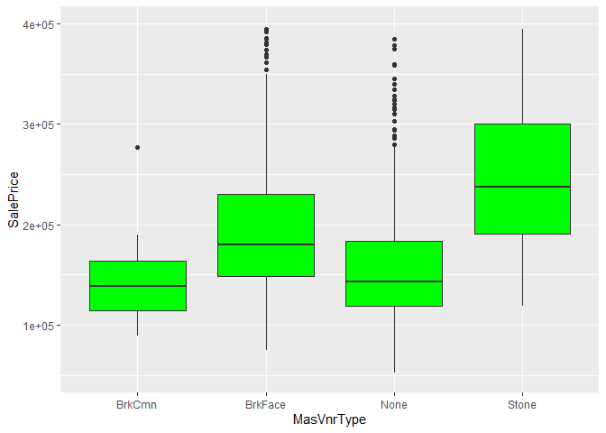

```r
#九、Masonry(砌体)：与砌体有关的变量(有两个)  => MasVnrType、MasVnrArea   (且都有缺失值，分别为24个、23个)

# MasVnrArea、与MasVnrType都为缺失值的房屋有多少个
length(which(is.na(all$MasVnrType) & is.na(all$MasVnrArea)))        #刚好23个 (MasVnrArea的缺失值个数)

# MasVnrArea不为缺失值，MasVnrType为缺失值的房屋
all[is.na(all$MasVnrType) & !is.na(all$MasVnrArea), c('MasVnrType', 'MasVnrArea')]     #这些房屋都有Masonry

#用(非'None')众数填充2611号房屋的MasVnrType  (2611栋房屋MasVnrArea不为NA，所以有Masonry，所以MasVnrType不能填'None')
all$MasVnrType[2611] = names(sort(-table(all$MasVnrType)))[2]
cat('\n')




#1、填充MasVnrType
length(table(all$MasVnrType))             #分类变量
table(all$MasVnrType)                     #(字符型)分类变量

all$MasVnrType[is.na(all$MasVnrType)] = 'None'

#   判断有序还是无序
qplot(MasVnrType, SalePrice, data=all, geom = 'boxplot',fill=I('green'), ylim=c(50000,400000))

#   (字符型)有序分类变量：标签编码
Masonry = c('None'=0, 'BrkCmn'=0, 'BrkFace'=1, 'Stone'=2)
all$MasVnrType = as.numeric(revalue(all$MasVnrType, Masonry))
table(all$MasVnrType)
cat('\n')




#2、填充MasVnrArea
length(table(all$MasVnrArea))             #连续型变量
table(all$MasVnrArea)[1:5]

#用众数填充
all$MasVnrArea[is.na(all$MasVnrArea)] = 0
```

```r
#十、MSZoning(住宅分区)

#填充MSZoning
length(table(all$MSZoning))             #分类变量
table(all$MSZoning)                     #(字符型)无序分类变量；转换为factor

#用众数填充
all$MSZoning[is.na(all$MSZoning)] = names(sort(-table(all$MSZoning)))[1]

#转换为factor
all$MSZoning = as.factor(all$MSZoning)
table(all$MSZoning)
```

```
[1] 5

C (all)      FV      RH      RL      RM
     25     139      26    2265     460

C (all)      FV      RH      RL      RM
     25     139      26    2269     460
```

```r
#十一、Utilities(可用设施)

#填充Utilities  (2个缺失值)
length(table(all$Utilities))             #分类变量
table(all$Utilities)                     #(字符型)有序分类变量；标签编码

#所以Utilities有2个缺失值、1个'NoSeWa'，其他2916个都为'AllPub'

#则此变量方差太小，对预测毫无用处，应该删除
all$Utilities=NULL
```

```
[1] 2

AllPub NoSeWa
  2916      1
```

```r
#十二、Functional(功能)

#填充Functional  (2个缺失值)
length(table(all$Functional))             #分类变量
table(all$Functional)                     #(字符型)有序分类变量；标签编码

#用众数填充缺失值
all$Functional[is.na(all$Functional)] = names(sort(-table(all$Functional)))[1]

#标签编码
all$Functional = as.numeric(revalue(all$Functional, c('Sal'=0, 'Sev'=1, 'Maj2'=2, 'Maj1'=3, 'Mod'=4, 'Min2'=5, 'Min1'=6, 'Typ'=7)))
table(all$Functional)
```

```
[1] 7

Maj1 Maj2 Min1 Min2  Mod  Sev  Typ
  19    9   65   70   35    2 2717

   1    2    3    4    5    6    7
   2    9   19   35   70   65 2719
```

```r
#十三、Exterior(外部的)：有关房屋外部的变量(有4个)  => Exterior1st、Exterior2nd、ExterQual、ExterCond
#其中前两个有缺失值(分别有1个缺失值)，后两个没有缺失值


#1、填充Exterior1st  (有1个缺失值)
length(table(all$Exterior1st))             #分类变量
table(all$Exterior1st)                     #(字符型)无序分类变量：转化为factor

#用众数填充缺失值
all$Exterior1st[is.na(all$Exterior1st)] = names(sort(-table(all$Exterior1st)))[1]

#转化为factor
all$Exterior1st = as.factor(all$Exterior1st)
table(all$Exterior1st)
cat('\n')




#2、填充Exterior2nd   (有1个缺失值)
length(table(all$Exterior2nd))             #分类变量
table(all$Exterior2nd)                     #(字符型)无序分类变量：转化为factor

#用众数填充缺失值
all$Exterior2nd[is.na(all$Exterior2nd)] = names(sort(-table(all$Exterior2nd)))[1]

#转化为factor
all$Exterior2nd = as.factor(all$Exterior2nd)
table(all$Exterior2nd)
cat('\n')




#3、ExterQual
length(table(all$ExterQual))             #分类变量
table(all$ExterQual)                     #(字符型)有序分类变量：标签编码

#标签编码
all$ExterQual=as.numeric(revalue(all$ExterQual, Qualities))
table(all$ExterQual)
cat('\n')




#4、ExterCond
length(table(all$ExterCond))             #分类变量
table(all$ExterCond)                     #(字符型)有序分类变量：标签编码

#标签编码
all$ExterCond=as.numeric(revalue(all$ExterCond, Qualities))
table(all$ExterCond)
```

```
[1] 15

AsbShng AsphShn BrkComm BrkFace  CBlock CemntBd HdBoard ImStucc MetalSd Plywood
     44       2       6      87       2     126     442       1     450     221
  Stone  Stucco VinylSd Wd Sdng WdShing
      2      43    1025     411      56

AsbShng AsphShn BrkComm BrkFace  CBlock CemntBd HdBoard ImStucc MetalSd Plywood
     44       2       6      87       2     126     442       1     450     221
  Stone  Stucco VinylSd Wd Sdng WdShing
      2      43    1026     411      56

[1] 16

AsbShng AsphShn Brk Cmn BrkFace  CBlock CmentBd HdBoard ImStucc MetalSd   Other
     38       4      22      47       3     126     406      15     447       1
Plywood   Stone  Stucco VinylSd Wd Sdng Wd Shng
    270       6      47    1014     391      81

AsbShng AsphShn Brk Cmn BrkFace  CBlock CmentBd HdBoard ImStucc MetalSd   Other
     38       4      22      47       3     126     406      15     447       1
Plywood   Stone  Stucco VinylSd Wd Sdng Wd Shng
    270       6      47    1015     391      81

[1] 4

  Ex   Fa   Gd   TA
 107   35  979 1798

   2    3    4    5
  35 1798  979  107

[1] 5

  Ex   Fa   Gd   Po   TA
  12   67  299    3 2538

   1    2    3    4    5
   3   67 2538  299   12
```

```r
#十四、Electrical(电力系统)

#填充Electrical(1个缺失值)
length(table(all$Electrical))             #分类变量
table(all$Electrical)                     #(字符型)无序分类变量：转化为factor

#用众数填充
all$Electrical[is.na(all$Electrical)] = names(sort(-table(all$Electrical)))[1]

#转化为factor
all$Electrical = as.factor(all$Electrical)
table(all$Electrical)
```

```
[1] 5

FuseA FuseF FuseP   Mix SBrkr
  188    50     8     1  2671

FuseA FuseF FuseP   Mix SBrkr
  188    50     8     1  2672
```

```r
#十五、Kitchen(厨房)：与厨房有关的变量(有两个)  => KitchenQual(有1个缺失值)、KitchenAbvGr(无缺失值)

#1、填充KitchenQual(1个缺失值)
length(table(all$KitchenQual))             #分类变量
table(all$KitchenQual)                     #(字符型)有序分类变量：标签编码

#用众数填充
all$KitchenQual[is.na(all$KitchenQual)] = 'TA'

#标签编码
all$KitchenQual=as.numeric(revalue(all$KitchenQual, Qualities))
table(all$KitchenQual)
cat('\n')




#2、KitchenAbvGr
length(table(all$KitchenAbvGr))             #分类变量
table(all$KitchenAbvGr)                     #(数值型)分类变量
```

```
[1] 4

  Ex   Fa   Gd   TA
 205   70 1151 1492

   2    3    4    5
  70 1493 1151  205

[1] 4

   0    1    2    3
   3 2785  129    2
```

```r
#十六、Sale：Sale开头的变量有两个(除了目标变量)  => SaleType、SaleCondition     (只有SaleType有缺失值)

#1、SaleType(1个缺失值)
length(table(all$SaleType))             #分类变量
table(all$SaleType)                     #(字符型)无序分类变量：转化为factor

#用众数填充缺失值
all$SaleType[is.na(all$SaleType)] = names(sort(-table(all$SaleType)))[1]

#转化为factor
all$SaleType = as.factor(all$SaleType)
table(all$SaleType)
cat('\n')




#2、SaleCondition
length(table(all$SaleType))             #分类变量
table(all$SaleType)                     #(字符型)无序分类变量：转化为factor

#转化为factor
all$SaleCondition = as.factor(all$SaleCondition)
```

```
[1] 9

  COD   Con ConLD ConLI ConLw   CWD   New   Oth    WD
   87     5    26     9     8    12   239     7  2525

  COD   Con ConLD ConLI ConLw   CWD   New   Oth    WD
   87     5    26     9     8    12   239     7  2526

[1] 9

  COD   Con ConLD ConLI ConLw   CWD   New   Oth    WD
   87     5    26     9     8    12   239     7  2526
```

## 2.3 剩余(字符)特征的处理

### 2.3.1 寻找剩余还是字符型的特征

```r
remain_char=names(all[,sapply(all,is.character)])
remain_char
```

```
 [1] "Street"       "LandContour"  "LandSlope"    "Neighborhood" "Condition1"
 [6] "Condition2"   "BldgType"     "HouseStyle"   "RoofStyle"    "RoofMatl"
[11] "Foundation"   "Heating"      "HeatingQC"    "CentralAir"   "PavedDrive"
```

### 2.3.2 处理剩余的字符特征

标签编码 + (one-hot encoding前)转化为factor

```r
#1、Street
length(table(all$Street))             #分类变量
table(all$Street)                     #(字符型)有序分类变量  =>Gravel(碎石)、Paved(铺好)：标签编码

#标签编码
all$Street = as.numeric(revalue(all$Street, c('Grvl'=0, 'Pave'=1)))
table(all$Street)
```

```
[1] 2

Grvl Pave
  12 2907

   0    1
  12 2907
```

```r
#2、Land开头的变量：LandContour、LandSlope

#1) LandContour
length(table(all$LandContour))             #分类变量
table(all$LandContour)                     #(字符型)无序分类变量：转化为factor

#转化为factor
all$LandContour = as.factor(all$LandContour)
cat('\n')




#2) LandSlope
length(table(all$LandSlope))             #分类变量
table(all$LandSlope)                     #(字符型)有序分类变量：标签编码

#标签编码
all$LandSlope = as.numeric(revalue(all$LandSlope, c('Sev'=0, 'Mod'=1, 'Gtl'=2)))
table(all$LandSlope)
```

```
[1] 4

 Bnk  HLS  Low  Lvl
 117  120   60 2622

[1] 3

 Gtl  Mod  Sev
2778  125   16

   0    1    2
  16  125 2778
```

```r
#3、Neighborhood
length(table(all$Neighborhood))             #分类变量  (level种类非常多的分类变量)
table(all$Neighborhood)                     #(字符型)无序分类变量：转化为factor

#转化为factor
all$Neighborhood = as.factor(all$Neighborhood)
```

```
[1] 25

Blmngtn Blueste  BrDale BrkSide ClearCr CollgCr Crawfor Edwards Gilbert  IDOTRR
     28      10      30     108      44     267     103     194     165      93
MeadowV Mitchel   NAmes NoRidge NPkVill NridgHt  NWAmes OldTown  Sawyer SawyerW
     37     114     443      71      23     166     131     239     151     125
Somerst StoneBr   SWISU  Timber Veenker
    182      51      48      72      24
```

```r
#4、以Condition开头的变量：Condition1、Condition2

#1) Condition1
length(table(all$Condition1))             #分类变量
table(all$Condition1)                     #(字符型)无序分类变量：转化为factor

#转化为factor
all$Condition1 = as.factor(all$Condition1)
cat('\n')




#2) Condition2
length(table(all$Condition2))             #分类变量
table(all$Condition2)                     #(字符型)无序分类变量：转化为factor

#转化为factor
all$Condition2 = as.factor(all$Condition2)
```

```
[1] 9

Artery  Feedr   Norm   PosA   PosN   RRAe   RRAn   RRNe   RRNn
    92    164   2511     20     39     28     50      6      9

[1] 8

Artery  Feedr   Norm   PosA   PosN   RRAe   RRAn   RRNn
     5     13   2889      4      4      1      1      2
```

```r
#5、BldgType
length(table(all$BldgType))             #分类变量
table(all$BldgType)                     #(字符型)无序分类变量：转化为factor

#转化为factor
all$BldgType = as.factor(all$BldgType)
```

```
[1] 5

  1Fam 2fmCon Duplex  Twnhs TwnhsE
  2425     62    109     96    227
```

```r
#6、HouseStyle
length(table(all$HouseStyle))             #分类变量
table(all$HouseStyle)                     #(字符型)无序分类变量：转化为factor


#转化为factor
all$HouseStyle = as.factor(all$HouseStyle)
```

```
[1] 8

1.5Fin 1.5Unf 1Story 2.5Fin 2.5Unf 2Story SFoyer   SLvl
   314     19   1471      8     24    872     83    128
```

```r
#7、Roof开头的变量：RoofStyle、RoofMatl

#1) RoofStyle
length(table(all$RoofStyle))             #分类变量
table(all$RoofStyle)                     #(字符型)无序分类变量：转化为factor

#转化为factor
all$RoofStyle = as.factor(all$RoofStyle)
cat('\n')




#2) RoofMatl
length(table(all$RoofMatl))             #分类变量
table(all$RoofMatl)                     #(字符型)无序分类变量：转化为factor

#转化为factor
all$RoofMatl = as.factor(all$RoofMatl)
```

```
[1] 6

   Flat   Gable Gambrel     Hip Mansard    Shed
     20    2310      22     551      11       5

[1] 8

ClyTile CompShg Membran   Metal    Roll Tar&Grv WdShake WdShngl
      1    2876       1       1       1      23       9       7
```

```r
#8、Foundation
length(table(all$Foundation))             #分类变量
table(all$Foundation)                     #(字符型)无序分类变量：转化为factor

#转化为factor
all$Foundation = as.factor(all$Foundation)
```

```
[1] 6

BrkTil CBlock  PConc   Slab  Stone   Wood
   311   1235   1308     49     11      5
```

```r
#9、以Heat开头的变量：Heating、HeatingQC

#1)Heating
length(table(all$Heating))             #分类变量
table(all$Heating)                     #(字符型)无序分类变量：转化为factor

#转化为factor
all$Heating = as.factor(all$Heating)
cat('\n')




#2)HeatingQC
length(table(all$HeatingQC))             #分类变量
table(all$HeatingQC)                     #(字符型)有序分类变量：标签编码

#标签编码
all$HeatingQC = as.numeric(revalue(all$HeatingQC, Qualities))
table(all$HeatingQC)
```

```
[1] 6

Floor  GasA  GasW  Grav  OthW  Wall
    1  2874    27     9     2     6

[1] 5

  Ex   Fa   Gd   Po   TA
1493   92  474    3  857

   1    2    3    4    5
   3   92  857  474 1493
```

```r
#10、CentralAir
length(table(all$CentralAir))             #分类变量
table(all$CentralAir)                     #(字符型)有序分类变量：标签编码

#标签编码
all$CentralAir = as.numeric(revalue(all$CentralAir, c('N'=0, 'Y'=1)))
table(all$CentralAir)
```

```
[1] 2

   N    Y
 196 2723

   0    1
 196 2723
```

```r
#11、PavedDrive
length(table(all$PavedDrive))             #分类变量
table(all$PavedDrive)                     #(字符型)有序分类变量：标签编码

#标签编码
all$PavedDrive = as.numeric(revalue(all$PavedDrive, c('N'=0, 'P'=1, 'Y'=2)))
table(all$PavedDrive)
```

```
[1] 3

   N    P    Y
 216   62 2641

   0    1    2
 216   62 2641
```

**以上就把所有特征都转化为数值型、和factor型 (没有字符特征了)。并且填充完所有缺失值 (除了test的SalePrice)**

# 3 可视化重要的特征

## 3.1 分出所有数值特征、和factor特征

```r
#分开所有的数值特征、和因子特征
numVar_index = which(sapply(all, is.numeric))      #数值特征的index向量(带name)
factorVar_index = which(sapply(all, is.factor))    #factor特征的index向量(带name)

numVar_name=names(all[,sapply(all, is.numeric)])       #或者用names(numVar_index)
factorVar_name=names(all[,sapply(all, is.factor)])     #或者用names(factorVar_index)
```

## 3.2 再次可视化协相关矩阵

可视化|与SalePrice相关性|>0.5的特征的协相关矩阵

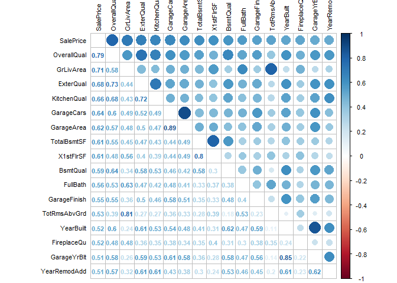

```r
all_numVar=all[,sapply(all, is.numeric)]
cor=cor(all_numVar, use="pairwise.complete.obs")    #忽略缺失值(SalePrice，建立cor)

cor_sorted=sort(cor['SalePrice',],decreasing = T)   #得到的是向量(带name)
cor_sorted=as.matrix(cor_sorted)                    #转化为matrix
corHigh_name=names(cor_sorted[abs(cor_sorted)>0.5,])     #选取matrix中满足条件的行

cor_high=cor[corHigh_name,corHigh_name]

corrplot::corrplot.mixed(cor_high, tl.col="black", tl.pos = "lt", tl.cex = 0.7,cl.cex = 0.7, number.cex=0.7)
#也可用corrplot::corrplot(cor_high, type = 'upper', diag = F, addCoef.col = 'black', tl.pos = "lt", cl.cex = 0.7, number.cex=0.7)
```

## 3.3 用随机森林可视化特征重要性(TOP20)

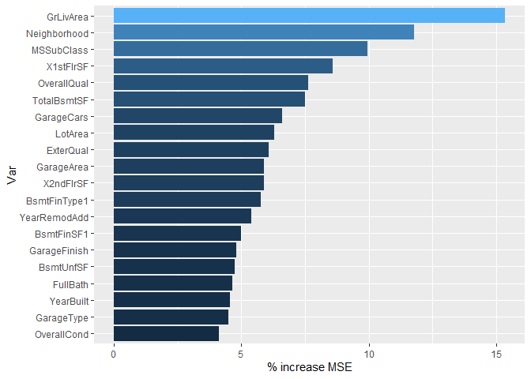

```r
#(用train)建立简单的随机森林      (只为了找到变量重要性  =>所以只设置100颗树)
quick_RF=randomForest(x=all[1:1460,-79], y=all[1:1460,79], ntree=100, importance =T)


#获得(由随机森林得到的)变量重要性       (并按重要性由小到大排好)
varImpo_RF=importance(quick_RF)
varImpo_df=data.frame(var=row.names(varImpo_RF), MSE=varImpo_RF[,1])
varImpo_df=varImpo_df[order(varImpo_df$MSE, decreasing=T),]
varImpoTop20_df=varImpo_df[1:20,]


#可视化前20的变量重要性
ggplot(varImpo_df[1:20,], aes(x=reorder(var, MSE), y=MSE, fill=MSE) ) + geom_bar(stat = 'identity') + labs(x = 'Var', y= '% increase MSE') + coord_flip() + theme(legend.position="none")
```

# 4 特征工程

## 4.1 新增特征

(新增特征：都是利用已有特征得到新特征的同行数据)

注意factor型的特征：不能直接使用。得用as.numeric()逆向转化后使用

所以在使用每个特征前，先用str()判断特征类型

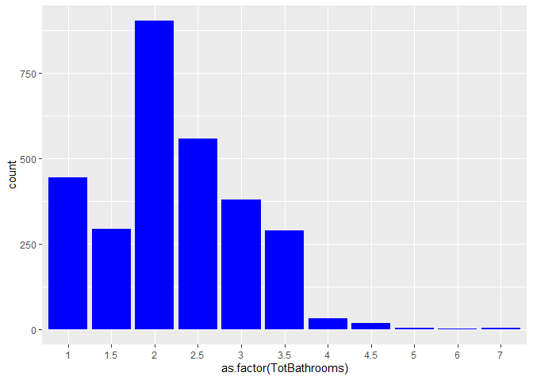

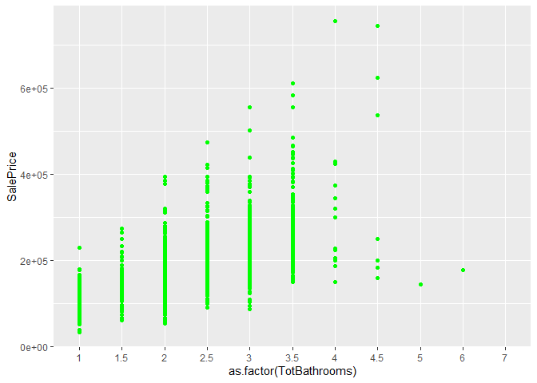

```r
#1、合并浴室变量 => 为总浴室数目(TotBathrooms)          (有4个浴室变量)
all$TotBathrooms = all$FullBath + (all$HalfBath*0.5) + all$BsmtFullBath + (all$BsmtHalfBath*0.5)
#TotBathrooms仍为(数值型)有序分类变量


#可视化新特征
qplot(as.factor(TotBathrooms), data=all, geom = 'bar', fill=I('blue'), ylab='count')
qplot(as.factor(TotBathrooms), SalePrice, data=all, col=I('green'))
```

售价与TotBathrooms正相关

```
 num [1:2919] 0 0 0 0 0 0 0 0 0 0 ...
```

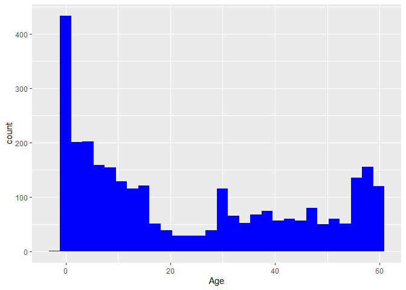

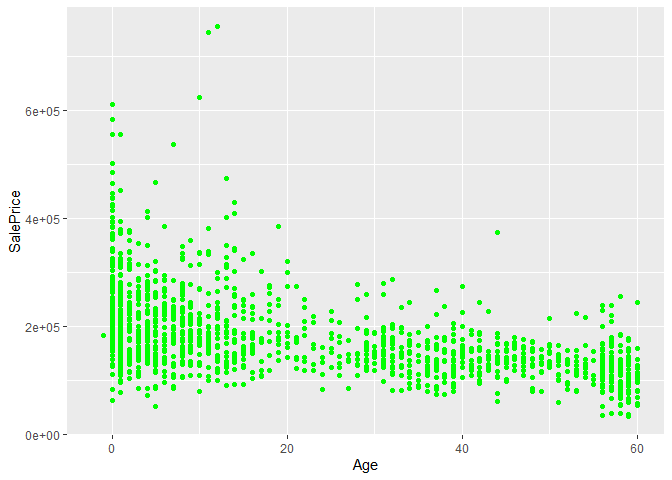

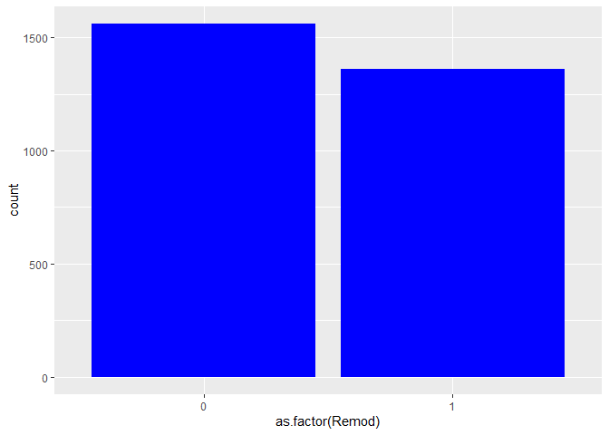

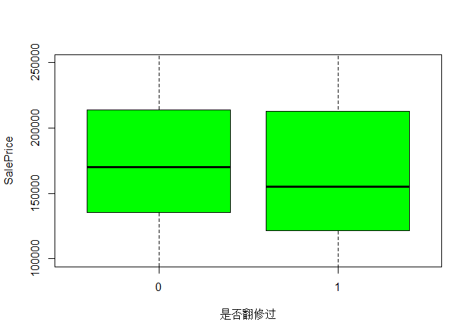

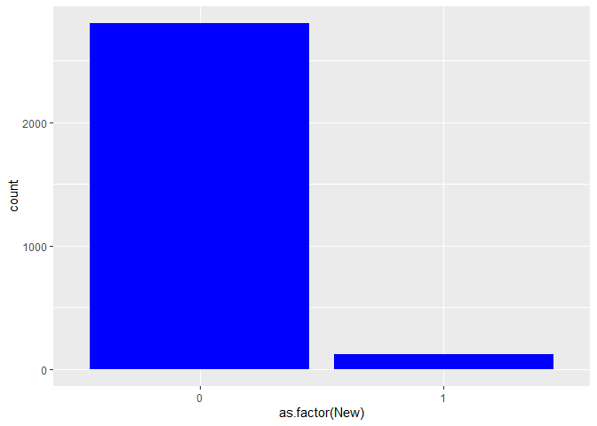

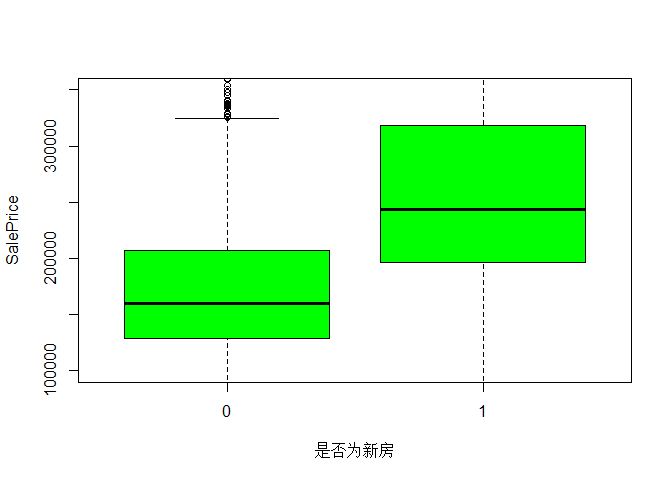

```r
#2、与Year有关的变量有3个  => YearBlt(建立年份)、YearRemodAdd(改造年份)、YearSold(售出年份)

#新增3个变量：                          (因为YrSold已被转换为factor型，所以以下使用时都应用as.character()将factor逆向)

#1) 房屋年龄(Age) ：   Age=YearSold-YearRemodAdd
all$Age = as.numeric(as.character(all$YrSold))-all$YearRemodAdd
#Age为连续型变量


#可视化Age
qplot(Age, data=all, geom ='histogram', fill=I('blue'), ylab='count')
qplot(Age, SalePrice, data=all, col=I('green'))




#2) 但是若YearRemodAdd!=YearBlt，则房屋售价应该更低(所以加入1个变量(是否翻修)：0/1 => 可视为惩罚参数)
all$Remod = ifelse(all$YearBuilt==all$YearRemodAdd, 0, 1)
#Remod为(数值型)有序分类变量


#可视化Remod
qplot(as.factor(Remod), data=all, geom='bar', fill=I('blue'), ylab='count')
boxplot(all$SalePrice~all$Remod, col='green', ylim=c(100000,250000),xlab='是否翻修过',ylab='SalePrice')




#3) 如果当年建好，当年卖出，则房屋售价应该更高
all$New = ifelse( as.numeric(as.character(all$YrSold)) ==all$YearBuilt, 1, 0)
#New为(数值型)有序分类变量:
str(all$New)


#可视化New
qplot(as.factor(New), data=all, geom='bar', fill=I('blue'), ylab='count')
boxplot(all$SalePrice~all$New, col='green', xlab='是否为新房', ylab='SalePrice', ylim=c(100000,350000))



#(数值型)有序分类变量，用factor形式画图与数值型画图效果不一样
```

售价与Age负相关， 售价与Remod也呈负相关， 售价与New呈正相关

```r
#3、合并Neighborhood中的level    => 新增变量；社区等级(Neighbor)

#Neighborhood是factor型变量，要用as.character()逆向转化

#按Neighborhood中不同的level分组，求median(SalePrice)   => 来区分不同Neighborhood的等级
SalePrice_complete=all[!is.na(all$SalePrice),]
mprice_Neighborhood_df=sqldf('select Neighborhood,median(SalePrice)as mPrice from SalePrice_complete group by Neighborhood')
mprice_Neighborhood_df=mprice_Neighborhood_df[order(mprice_Neighborhood_df$mPrice, decreasing = T) , ]


#所以，增加一个新变量：社区等级(Neighbor)
all$Neighbor=1            #必须要用数值初始化(想要得到数值型变量时)，不然会转化为factor型(得到的是factor型变量)
str(all$Neighbor)

#分别合并昂贵社区、平穷社区、以及剩下的社区 => 为Neighbor3个level
all$Neighbor[as.character(all$Neighborhood) %in% c('StoneBr', 'NridgHt', 'NoRidge')] = 2
all$Neighbor[as.character(all$Neighborhood) %in% c('MeadowV', 'IDOTRR', 'BrDale')] = 0
all$Neighbor[! as.character(all$Neighborhood) %in% c('MeadowV', 'IDOTRR', 'BrDale', 'StoneBr', 'NridgHt', 'NoRidge')] = 1
#Neighbor为(数值型)有序分类变量
str(all$Neighbor)         #得到的是数值型变量
table(all$Neighbor)
```

```
 num [1:2919] 1 1 1 1 1 1 1 1 1 1 ...
 num [1:2919] 1 1 1 1 2 1 1 1 1 1 ...

   0    1    2
 160 2471  288
```